# Multiple Linear Regression1

# jitter() adds a small amount of noise to a numeric vector which solved the overplotting problem.

More than natural variation? Let’s see if the apparent trend in the plot is something more than natural variation.

Fit a linear model called m_bty to predict average professor score by average beauty rating and add the line to your plot using abline(m_bty).

Instructions Construct the linear model m_bty. Add the linear model to the plot with the help of abline(m_bty). Write out the equation for the linear model yourself, and interpret the slope.

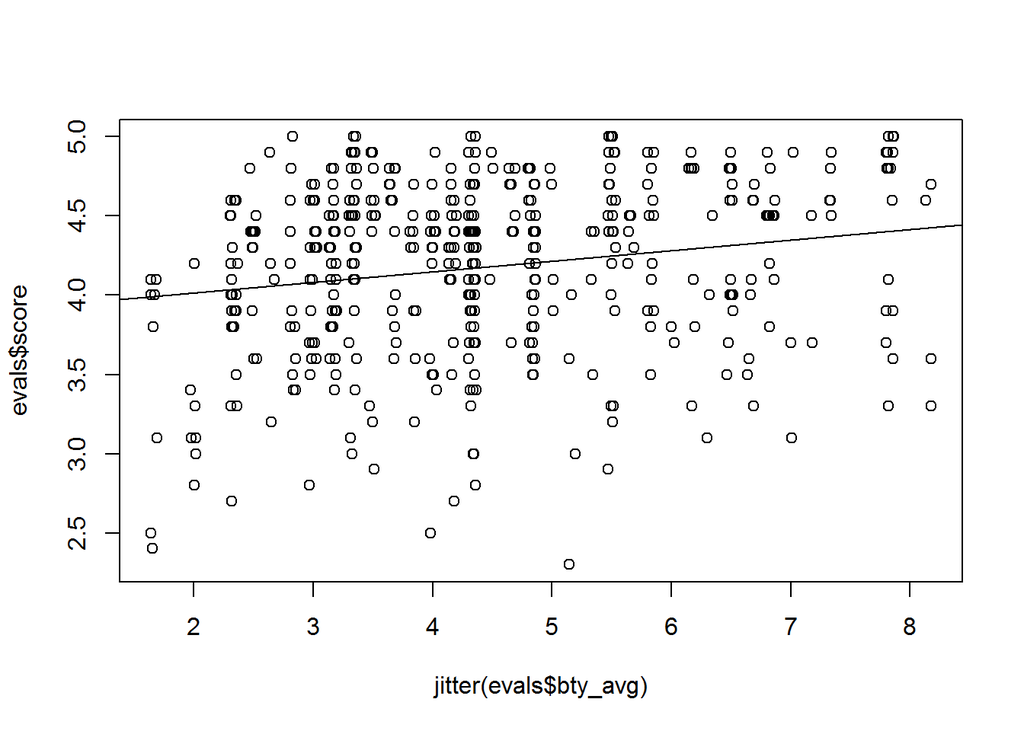

```r
# Initial plot
plot(evals$score ~ jitter(evals$bty_avg))

# Construct the linear model
m_bty <- lm(score ~ bty_avg, data = evals)

# Plot the linear model on the initial plot
abline(m_bty)
```

Multiple linear regression The data set contains several variables on the beauty score of the professor:

individual ratings from each of the six students who were asked to score the physical appearance of the professors and the average of these six scores.

Let’s take a look at the relationship between one of these scores and the average beauty score.

Instructions Create a scatterplot with the beauty rating of professor from lower level female bty_f1lower and the average beauty score bty_avg.

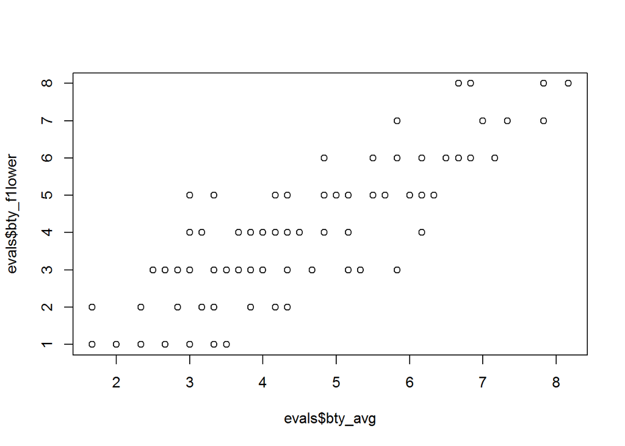

```r
# Initial scatterplot
plot(evals$bty_f1lower ~ evals$bty_avg)
```

Indeed. As expected, the relationship is quite strong.

The relationship between all beauty variables. As seen in the previous exercise, the relationship is quite strong; after all, the average score is calculated using the individual scores.

We can actually take a look at the relationships between all beauty variables (columns 13 through 19) using the following command.

Instructions Have a look at the relationships between all beauty variables (columns 13 through 19).

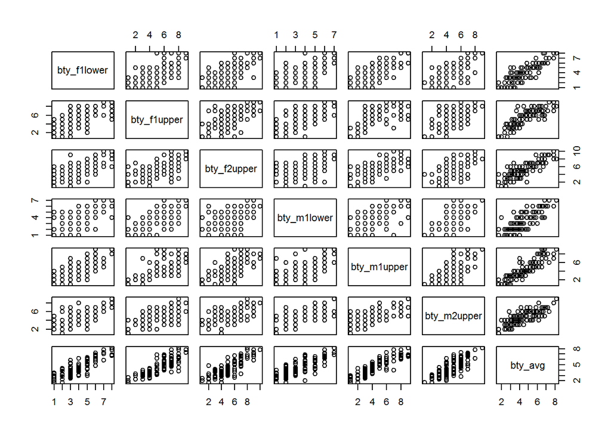

```r
plot(evals[, 13:19])
```

These variables are collinear (correlated), and adding more than one of these variables to the model would not add much value to the model.

In this application and with these highly-correlated predictors, it is reasonable to use the average beauty score as the single representative of these variables.

Taking into account gender In order to see if beauty is still a significant predictor of professor score after we’ve accounted for the gender is the professor, we can add the gender term into the model.

Instructions Fit a linear model called m_bty_gen to predict average professor score by average beauty rating bty_avg and by gender.

You can use the + sign to add more explanatory variables to the model. Study the outcome with the help of summary().

```r
# The new linear model
m_bty_gen <- lm(score ~ bty_avg + gender, data = evals)

# Study the outcome
summary(m_bty_gen)
```

```
##
## Call:
## lm(formula = score ~ bty_avg + gender, data = evals)
##
## Residuals:
##     Min      1Q  Median      3Q     Max
## -1.8305 -0.3625  0.1055  0.4213  0.9314
##
## Coefficients:
##             Estimate Std. Error t value Pr(>|t|)
## (Intercept)  3.74734    0.08466  44.266  < 2e-16 ***
## bty_avg      0.07416    0.01625   4.563 6.48e-06 ***
## gendermale   0.17239    0.05022   3.433 0.000652 ***
## ---
## Signif. codes:  0 '***' 0.001 '**' 0.01 '*' 0.05 '.' 0.1 ' ' 1
##
## Residual standard error: 0.5287 on 460 degrees of freedom
## Multiple R-squared:  0.05912,    Adjusted R-squared:  0.05503
## F-statistic: 14.45 on 2 and 460 DF,  p-value: 8.177e-07
```

Look closely at the outcome of summary.

Is bty_avg still a significant predictor of score?

Has the addition of gender to the model changed the parameter estimate for bty_avg?

P-Values P-values and parameter estimates should only be trusted if the conditions for the regression are reasonable.

Using diagnostic plots, can we conclude that the conditions for this model are reasonable?

Gendermale Note that the estimate for gender is called gendermale in your summary output.

You’ll see this name change whenever you introduce a categorical variable.

The reason is that R recodes gender from having the values of female and male to being an indicator variable called gendermale that takes a value of 0 for females and a value of 1 for males. (Such variables are often referred to as ‘dummy’ variables.)

As a result, for females, the parameter estimate is multiplied by zero, leaving the intercept and slope form familiar from simple regression.

score^ = b0 + b1 × bty_avg + b2 × (0) = b0 + b1 × bty_avg

Instructions Plot this line and the line corresponding to males with the following custom function

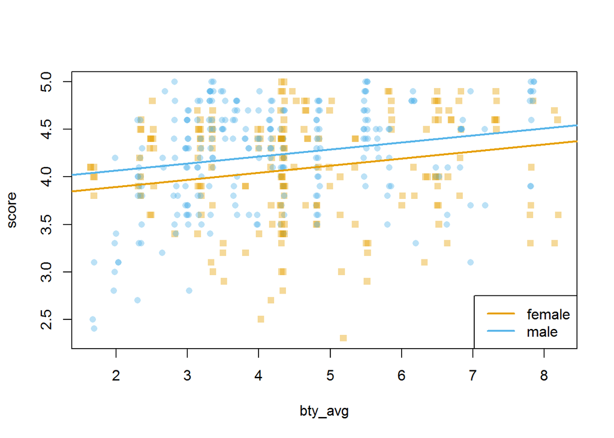

```r
multiLines(m_bty_gen)
```

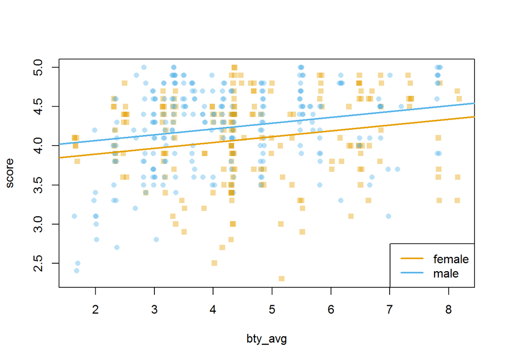

```r
# The plot
multiLines(m_bty_gen)
```

Try to determine the equation of the line corresponding to males yourself.

(Hint: For males, the parameter estimate is multiplied by 1.)

For your information, the decision to call the indicator variable gendermale instead of genderfemale has no deeper meaning.

R simply codes the category that comes first alphabetically as a 0.

Switching rank and gender Create a new model called m_bty_rank with gender removed and rank added in.

Instructions Fit a linear model called m_bty_rank to predict average professor score by average beauty rating bty_avg and by rank (add the two variables).

Print the outcome with the help of summary().

How does R appear to handle categorical variables that have more than two levels?

Note that the rank variable has three levels: teaching, tenure track, tenured.

```r
# The linear model with rank and average beauty
m_bty_rank <- lm(score ~ bty_avg + rank, data = evals)

# View the regression output
summary(m_bty_rank)
```

```
##
## Call:
## lm(formula = score ~ bty_avg + rank, data = evals)
##
## Residuals:
##     Min      1Q  Median      3Q     Max
## -1.8713 -0.3642  0.1489  0.4103  0.9525
##
## Coefficients:
##                  Estimate Std. Error t value Pr(>|t|)
## (Intercept)       3.98155    0.09078  43.860  < 2e-16 ***
## bty_avg           0.06783    0.01655   4.098 4.92e-05 ***
## ranktenure track -0.16070    0.07395  -2.173   0.0303 *
## ranktenured      -0.12623    0.06266  -2.014   0.0445 *
## ---
## Signif. codes:  0 '***' 0.001 '**' 0.01 '*' 0.05 '.' 0.1 ' ' 1
##
## Residual standard error: 0.5328 on 459 degrees of freedom
## Multiple R-squared:  0.04652,    Adjusted R-squared:  0.04029
## F-statistic: 7.465 on 3 and 459 DF,  p-value: 6.88e-05
```

Since rank has three levels (teaching, tenure track, tenured) two indicator variables are created:

one for tenure track and and one for tenured.

Teaching is the reference level hence it doesn’t show up in the regression output.

Brainstorming: Which of the following is the correct order of the three levels of rank if we were to order them from lowest predicted course evaluation score to highest predicted course evaluation score?

Instructions Teaching, Tenure Track, Tenured Tenure track, Tenured Tenure Track, Tenured, Teaching Teaching, Tenured, Tenure Track

Well! In general, the interpretation of the coefficients in multiple regression is slightly different from that of simple regression.

The estimate for bty_avg reflects how much higher a group of professors is expected to score if they have a beauty rating that is one point higher while holding all other variables constant.

In this case, that translates into considering only professors of the same rank with bty_avg scores that are one point apart.

Note you do not included the pic_outfit or pic_color variables in the full model because the original study states that these variables were used in a different analysis evaluating whether they’re related to how highly the six students involved in the study score the professors’ beauty (not related to how the students evaluate their professors in class).

Instructions Before running the model, think about which variable you would expect to have the highest p-value in this model and why.

Run the full model, the code is displayed in the editor.

Print the summary of the m_full model.

```r
# The full model:
m_full <- lm(score ~ rank + ethnicity + gender + language + age + cls_perc_eval + cls_students + cls_level + cls_profs + cls_credits + bty_avg, data = evals)

# View the regression output:
summary(m_full)
```

```
##
## Call:
## lm(formula = score ~ rank + ethnicity + gender + language + age +
##     cls_perc_eval + cls_students + cls_level + cls_profs + cls_credits +
##     bty_avg, data = evals)
##
## Residuals:
##      Min       1Q   Median       3Q      Max
## -1.84482 -0.31367  0.08559  0.35732  1.10105
##
## Coefficients:
##                         Estimate Std. Error t value Pr(>|t|)
## (Intercept)            3.5305036  0.2408200  14.660  < 2e-16 ***
## ranktenure track      -0.1070121  0.0820250  -1.305 0.192687
## ranktenured           -0.0450371  0.0652185  -0.691 0.490199
## ethnicitynot minority  0.1869649  0.0775329   2.411 0.016290 *
## gendermale             0.1786166  0.0515346   3.466 0.000579 ***
## languagenon-english   -0.1268254  0.1080358  -1.174 0.241048
## age                   -0.0066498  0.0030830  -2.157 0.031542 *
## cls_perc_eval          0.0056996  0.0015514   3.674 0.000268 ***
## cls_students           0.0004455  0.0003585   1.243 0.214596
## cls_levelupper         0.0187105  0.0555833   0.337 0.736560
## cls_profssingle       -0.0085751  0.0513527  -0.167 0.867458
## cls_creditsone credit  0.5087427  0.1170130   4.348  1.7e-05 ***
## bty_avg                0.0612651  0.0166755   3.674 0.000268 ***
## ---
## Signif. codes:  0 '***' 0.001 '**' 0.01 '*' 0.05 '.' 0.1 ' ' 1
##
## Residual standard error: 0.504 on 450 degrees of freedom
## Multiple R-squared:  0.1635, Adjusted R-squared:  0.1412
## F-statistic: 7.331 on 12 and 450 DF,  p-value: 2.406e-12
```

Make sure to check your suspicions on which variable you expected to have the highest p-value in this model.

Brainstorming Which of the following is the correct interpretation of the coefficient associated with the ethnicity variable.

Non-minority professors are expected on average to score…

Note: your model m_full is still loaded in the workspace. Check the summary.

Instructions 0.19 points lower than minority professors, all else held constant. 0.19 points higher than minority professors, all else held constant. (correct) 0.02 points lower than minority professors, all else held constant. 0.02 points higher than minority professors, all else held constant.

Eliminating variables from the model - p-value selection Now you will create a new model, where you will drop the variable with the highest p-value in the m_full model.

Instructions Create the model m_new, where the variable with the highest p-value of the m_full is left out.

Have a look at the summary of the m_new model.

Did the coefficients and significance of the other explanatory variables change?

```r
# The full model
m_full <- lm(score ~ rank + ethnicity + gender + language + age + cls_perc_eval + cls_students + cls_level + cls_profs + cls_credits + bty_avg, data = evals)

# The new model
m_new <- lm(score ~ rank + ethnicity + gender + language + age + cls_perc_eval + cls_students + cls_level + cls_credits + bty_avg, data = evals)

# View the regression output
summary(m_new)
```

```
##
## Call:
## lm(formula = score ~ rank + ethnicity + gender + language + age +
##     cls_perc_eval + cls_students + cls_level + cls_credits +
##     bty_avg, data = evals)
##
## Residuals:
##      Min       1Q   Median       3Q      Max
## -1.85048 -0.31394  0.08052  0.35956  1.10356
##
## Coefficients:
##                         Estimate Std. Error t value Pr(>|t|)
## (Intercept)            3.5286297  0.2402990  14.684  < 2e-16 ***
## ranktenure track      -0.1073638  0.0819096  -1.311 0.190606
## ranktenured           -0.0453744  0.0651169  -0.697 0.486278
## ethnicitynot minority  0.1893718  0.0760992   2.488 0.013189 *
## gendermale             0.1780270  0.0513581   3.466 0.000578 ***
## languagenon-english   -0.1265737  0.1079088  -1.173 0.241427
## age                   -0.0066619  0.0030788  -2.164 0.031006 *
## cls_perc_eval          0.0056790  0.0015448   3.676 0.000265 ***
## cls_students           0.0004493  0.0003573   1.257 0.209319
## cls_levelupper         0.0183743  0.0554870   0.331 0.740687
## cls_creditsone credit  0.5109162  0.1161614   4.398 1.36e-05 ***
## bty_avg                0.0611497  0.0166432   3.674 0.000267 ***
## ---
## Signif. codes:  0 '***' 0.001 '**' 0.01 '*' 0.05 '.' 0.1 ' ' 1
##
## Residual standard error: 0.5035 on 451 degrees of freedom
## Multiple R-squared:  0.1635, Adjusted R-squared:  0.1431
## F-statistic: 8.012 on 11 and 451 DF,  p-value: 8.303e-13
```

Note: If you look at the summary, you see that the coefficients and p-values of some variables changed.

One of the things that makes multiple regression interesting is that coefficient estimates depend on the other variables that are included in the model.

Eliminating variables from the model - adjusted R-squared selection Now you will create a new model, where you will drop the variable that when dropped yields the highest improvement in the adjusted R2.

Instructions Create a new model, m1, where you remove rank from the list of explanatory variables.

Check out the adjusted R2 of this new model and compare it to the adjusted R2 of the full model.

If you don’t want to view the entire model output, but just the adjusted R-squared, use

summary(m1)$adj.r.squared.

Create another new model, m2, where you remove ethnicity from the list of explanatory variables.

Check out the adjusted R2 of this new model and compare it to the adjusted R2 of the full model.

Repeat until you have tried removing each variable from the full model m_full at a time, and determine the removal of which variable yields the highest improvement in the adjusted R-sqared.

Make note of this variable (you will be asked about it in the following session).

```r
# The full model:
m_full <- lm(score ~ rank + ethnicity + gender + language + age + cls_perc_eval + cls_students + cls_level + cls_profs + cls_credits + bty_avg, data = evals)
summary(m_full)$adj.r.squared
```

```
## [1] 0.1412172
```

```r
# Remove rank:
m1 <- lm(score ~ ethnicity + gender + language + age + cls_perc_eval + cls_students + cls_level + cls_profs + cls_credits + bty_avg, data = evals)
summary(m1)$adj.r.squared
```

```
## [1] 0.1417823
```

```r
# Remove ethnicity:
m2 <- lm(score ~ rank + gender + language + age + cls_perc_eval + cls_students + cls_level + cls_profs + cls_credits + bty_avg, data = evals)
summary(m2)$adj.r.squared
```

```
## [1] 0.1320486
```

```r
# Remove gender:
m3 <- lm(score ~ rank + ethnicity + language + age + cls_perc_eval + cls_students + cls_level + cls_profs + cls_credits + bty_avg, data = evals)
summary(m3)$adj.r.squared
```

```
## [1] 0.1202468
```

```r
# Remove language:
m4 <- lm(score ~ rank + ethnicity + gender + age + cls_perc_eval + cls_students + cls_level + cls_profs + cls_credits + bty_avg, data = evals)
summary(m4)$adj.r.squared
```

```
## [1] 0.1404972
```

```r
# Remove age:
m5 <- lm(score ~ rank + ethnicity + gender + language + cls_perc_eval + cls_students + cls_level + cls_profs + cls_credits + bty_avg, data = evals)
summary(m5)$adj.r.squared
```

```
## [1] 0.1342627
```

```r
# Remove cls_perc_eval:
m6 <- lm(score ~ rank + ethnicity + gender + language + age + cls_students + cls_level + cls_profs + cls_credits + bty_avg, data = evals)
summary(m6)$adj.r.squared
```

```
## [1] 0.1174213
```

```r
# Remove cls_students:
m7 <- lm(score ~ rank + ethnicity + gender + language + age + cls_perc_eval + cls_level + cls_profs + cls_credits + bty_avg, data = evals)
summary(m7)$adj.r.squared
```

```
## [1] 0.1401804
```

```r
# Remove cls_level:
m8 <- lm(score ~ rank + ethnicity + gender + language + age + cls_perc_eval + cls_students + cls_profs + cls_credits + bty_avg, data = evals)
summary(m8)$adj.r.squared
```

```
## [1] 0.1429056
```

```r
# Remove cls_profs:
m9 <- lm(score ~ rank + ethnicity + gender + language + age + cls_perc_eval + cls_students + cls_level + cls_credits + bty_avg, data = evals)
summary(m9)$adj.r.squared
```

```
## [1] 0.1430683
```

```r
# Remove cls_credits:
m10 <- lm(score ~ rank + ethnicity + gender + language + age + cls_perc_eval + cls_students + cls_level + cls_profs + bty_avg, data = evals)
summary(m10)$adj.r.squared
```

```
## [1] 0.107127
```

```r
# Remove bty_avg:
m11 <- lm(score ~ rank + ethnicity + gender + language + age + cls_perc_eval + cls_students + cls_level + cls_profs + cls_credits, data = evals)
summary(m11)$adj.r.squared
```

```
## [1] 0.1174189
```

Take some time to reflect on this final model.

Based on your final model, what are the characteristics of a professor and course at University of Texas at Austin that would be associated with a high evaluation score?

Would you be comfortable generalizing your conclusions to apply to professors generally (at any university)? Why or why not?

Elimination of which variable from the full model yielded the highest adjusted R-squared?

Instructions

bty_avg  
cls_profs  
cls_students  
rank